# Rep Research Peer Assessment 1

Vince Glick

Sunday, February 15, 2015

```r
echo = TRUE
options(scipen = 1)
```

#### Loading and preprocessing the data

```r
require(ggplot2)
```

**1. Load the data (i.e. read.csv() )**

```r
activity <- read.csv("activity.csv", colClasses = c("integer", "Date", "factor"))
```

**2. Process/transform the data (if necessary) into a format suitable for your analysis**

```r
activclean <- na.omit(activity)
activity$month <- as.numeric(format(activity$date, "%m"))
```

#### What is mean total number of steps taken per day?

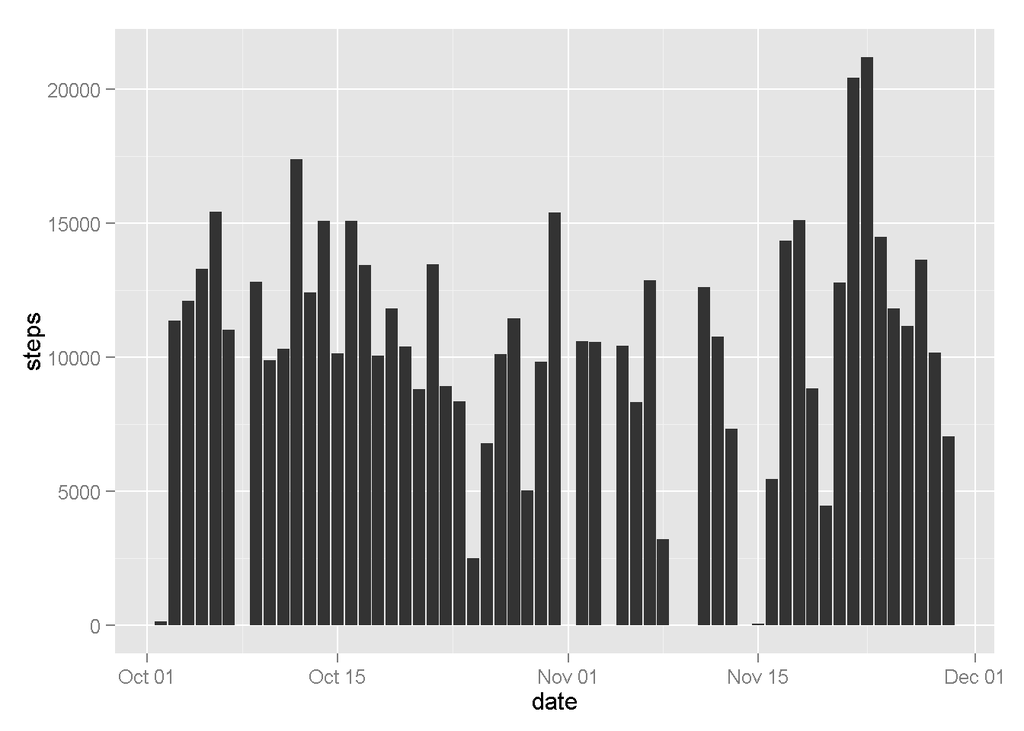

```r
gbarplot <- ggplot(data=activclean , aes(x=date, y=steps))+ geom_bar(stat = "identity")
gbarplot
```

**2. Calculate and report the mean and median total number of steps taken per day**

```r
aggregate_steps <- aggregate(activclean$steps, list(date = activclean$date), FUN = "sum")$x

meanAvgSteps <- mean(aggregate_steps)
meanAvgSteps
```

```
## [1] 10766.19
```

```r
medianAvgSteps <- median(aggregate_steps)
medianAvgSteps
```

```
## [1] 10765
```

#### What is the average daily activity pattern?

**1. Make a time series plot (i.e. type = “l” ) of the 5minute interval (xaxis)** **and the average number of steps taken, averaged across all days (yaxis)**

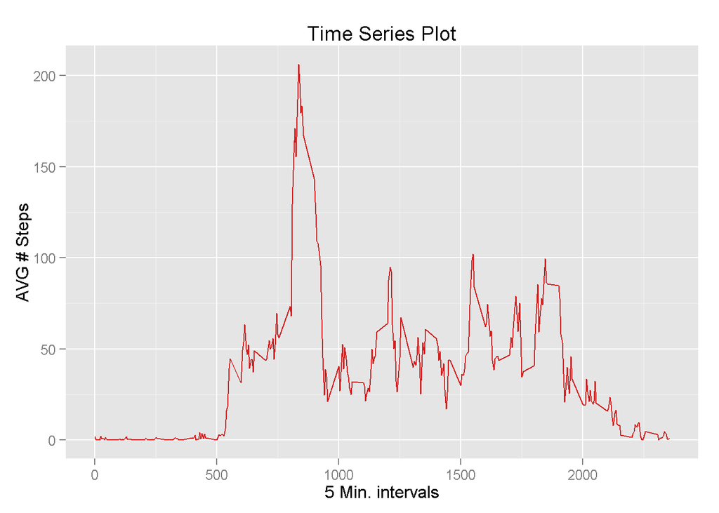

```r
avgsteps <- aggregate(activclean$steps, list(interval = as.numeric(as.character(activclean$interval))),
                      FUN = "mean")
names(avgsteps)[2] <- "meanAvgSteps"

ggplot(avgsteps, aes(interval, meanAvgSteps)) +
  geom_line(color = "#d41e1e", size = 0.5) +
  labs(title = "Time Series Plot", x = "5 Min. intervals", y = "AVG # Steps")
```

```r
head(activclean)
```

```
##     steps       date interval
## 289     0 2012-10-02        0
## 290     0 2012-10-02        5
## 291     0 2012-10-02       10
## 292     0 2012-10-02       15
## 293     0 2012-10-02       20
## 294     0 2012-10-02       25
```

**2. Which 5-minute interval, on average across all the days in the dataset,** **contains the maximum number of steps?**

```r
avgsteps[avgsteps$meanAvgSteps==max(avgsteps$meanAvgSteps),]
```

```
##     interval meanAvgSteps
## 104      835     206.1698
```

#### Imputing missing values

**1. Calculate and report the total number of missing values in the dataset** **(i.e. the total number of rows with NA s)**

```r
sum(is.na(activity[1]))
```

```
## [1] 2304
```

**2. Devise a strategy for filling in all of the missing values in the dataset. The strategy does not need to** **be sophisticated. For example, you could use the mean/median for that day, or the mean for that 5minute** **interval, etc.**

**3. Create a new dataset that is equal to the original dataset but with the missing data filled in.**

```r
fillActivity <- activity
for (i in 1:nrow(fillActivity)) {
  if (is.na(fillActivity$steps[i])) {
    fillActivity$steps[i] <- avgsteps[which(fillActivity$interval[i] == avgsteps$interval), ]$meanAvgSteps
  }
}

head(fillActivity)
```

```
##       steps       date interval month
## 1 1.7169811 2012-10-01        0    10
## 2 0.3396226 2012-10-01        5    10
## 3 0.1320755 2012-10-01       10    10
## 4 0.1509434 2012-10-01       15    10
## 5 0.0754717 2012-10-01       20    10
## 6 2.0943396 2012-10-01       25    10
```

```r
sum(is.na(fillActivity[1]))
```

```
## [1] 0
```

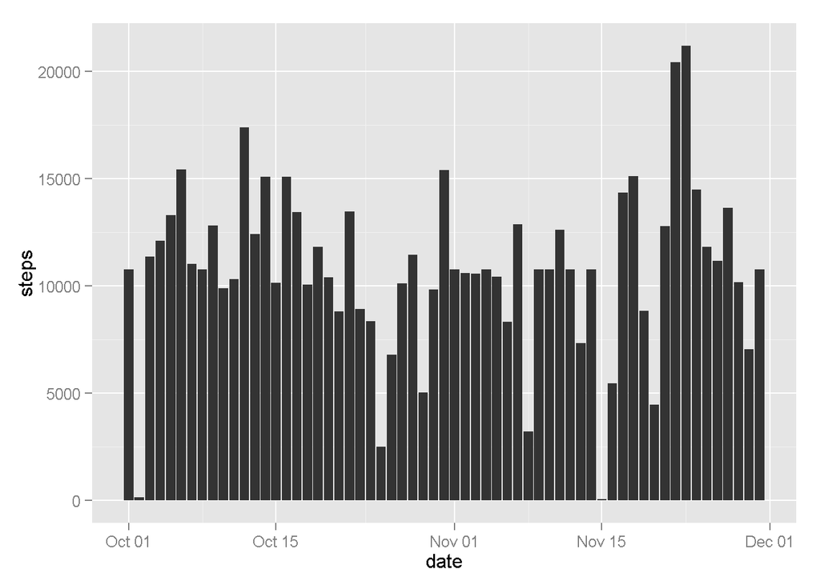

```r
gbarplot2 <- ggplot(data=fillActivity, aes(x=date, y=steps))+ geom_bar(stat = "identity")
gbarplot2
```

```r
avgsteps2 <- aggregate(fillActivity$steps, list(interval = as.numeric(as.character(fillActivity$interval))),
                       FUN = "mean")$x
meanAvgSteps2 <- mean(avgsteps2)
meanAvgSteps2
```

```
## [1] 37.3826
```

```r
medianAvgSteps2 <- median(avgsteps2)
medianAvgSteps2
```

```
## [1] 34.11321
```

#### What is the impact of imputing missing data on the estimates of the total

#### daily number of steps?

```r
aggregate_steps2 <- aggregate(fillActivity$steps, list(date = fillActivity$date), FUN = "sum")$x


t.test(aggregate_steps, aggregate_steps2)
```

```
##
##  Welch Two Sample t-test
##
## data:  aggregate_steps and aggregate_steps2
## t = 0, df = 107.145, p-value = 1
## alternative hypothesis: true difference in means is not equal to 0
## 95 percent confidence interval:
##  -1539.144  1539.144
## sample estimates:
## mean of x mean of y
##  10766.19  10766.19
```

```r
wilcox.test(aggregate_steps, aggregate_steps2)
```

```
##
##  Wilcoxon rank sum test with continuity correction
##
## data:  aggregate_steps and aggregate_steps2
## W = 1612.5, p-value = 0.9841
## alternative hypothesis: true location shift is not equal to 0
```

```r
var.test(aggregate_steps, aggregate_steps2)
```

```
##
##  F test to compare two variances
##
## data:  aggregate_steps and aggregate_steps2
## F = 1.1538, num df = 52, denom df = 60, p-value = 0.5901
## alternative hypothesis: true ratio of variances is not equal to 1
## 95 percent confidence interval:
##  0.6822128 1.9714650
## sample estimates:
## ratio of variances
##           1.153846
```

#### Are there differences in activity patterns between weekdays and weekends?

**1. Create a new factor variable in the dataset with two levels - “weekday” and “weekend” indicating** **whether a given date is a weekday or weekend day.**

```r
head(fillActivity)
```

```
##       steps       date interval month
## 1 1.7169811 2012-10-01        0    10
## 2 0.3396226 2012-10-01        5    10
## 3 0.1320755 2012-10-01       10    10
## 4 0.1509434 2012-10-01       15    10
## 5 0.0754717 2012-10-01       20    10
## 6 2.0943396 2012-10-01       25    10
```

```r
fillActivity$day <- factor(format(fillActivity$date, "%A"))
levels(fillActivity$day)
```

```
## [1] "Friday"    "Monday"    "Saturday"  "Sunday"    "Thursday"  "Tuesday"
## [7] "Wednesday"
```

```r
levels(fillActivity$day) <-
  list(weekday = c("Monday", "Tuesday", "Wednesday", "Thursday", "Friday"),
       weekend = c("Saturday", "Sunday"))
head(fillActivity)
```

```
##       steps       date interval month     day
## 1 1.7169811 2012-10-01        0    10 weekday
## 2 0.3396226 2012-10-01        5    10 weekday
## 3 0.1320755 2012-10-01       10    10 weekday
## 4 0.1509434 2012-10-01       15    10 weekday
## 5 0.0754717 2012-10-01       20    10 weekday
## 6 2.0943396 2012-10-01       25    10 weekday
```

**2. Make a panel plot containing a time series plot (i.e. type = “l” ) of the 5minute** **interval (xaxis) and the average number of steps taken, averaged across all weekday** **days or weekend days (yaxis). See the README file in the GitHub repository to see an** **example of what this plot should look like using simulated data.**

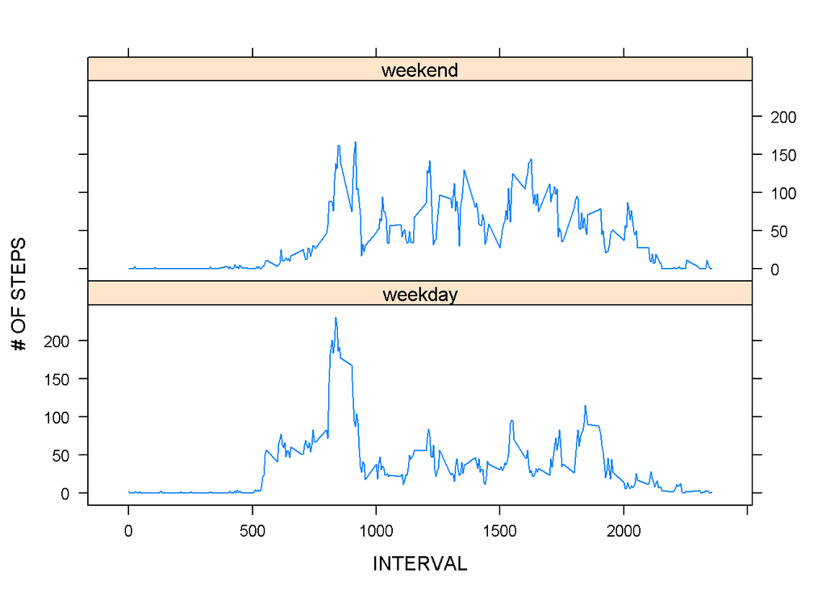

```r
avgsteps <- aggregate(fillActivity$steps,
                      list(interval = as.numeric(as.character(fillActivity$interval)),
                           day = fillActivity$day),
                      FUN = "mean")
names(avgsteps)[3] <- "meanSteps"
library(lattice)
xyplot(avgsteps$meanSteps ~ avgsteps$interval | avgsteps$day,
       layout = c(1, 2), type = "l",
       xlab = "INTERVAL", ylab = "# OF STEPS")
```